# Logistic Regression and Basis Function Expansion

Predicting diabetes from plasma glucose and age

## Data

The [Pima Indians Diabetes](https://www.kaggle.com/datasets/uciml/pima-indians-diabetes-database) dataset contains medical measurements for 768 women of Pima heritage, together with whether they were diagnosed with diabetes. We model diabetes using two predictors: **plasma glucose concentration** and **age**.

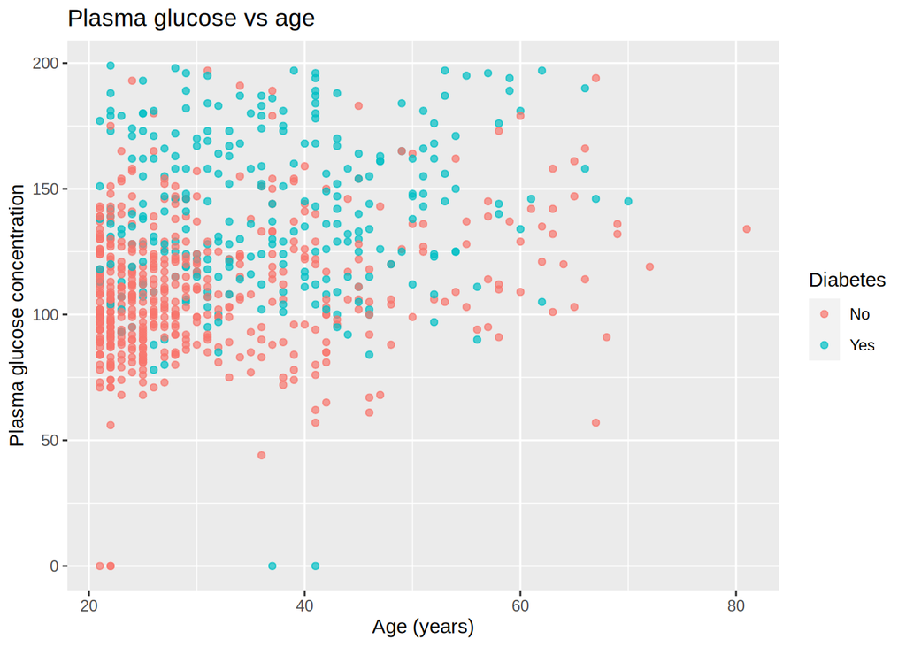

```r
df <- read.csv("../data/pima-indians-diabetes.csv", header = FALSE)
colnames(df) <- c("pregnancies", "glucose", "blood_pressure", "skin_thickness",
                  "insulin", "bmi", "pedigree", "age", "diabetes")
df$diabetes_label <- factor(df$diabetes, levels = c(0, 1), labels = c("No", "Yes"))

ggplot(df, aes(x = age, y = glucose, colour = diabetes_label)) +
  geom_point(alpha = 0.7) +
  labs(title = "Plasma glucose vs age", x = "Age (years)",
       y = "Plasma glucose concentration", colour = "Diabetes")
```

Diabetic patients tend to have higher glucose levels, but the two classes overlap heavily, so a model using only these two features will not separate them perfectly.

## Logistic regression

$$P(\text{diabetes} = 1 \mid x) = \frac{1}{1 + e^{-(\theta_0 + \theta_1
\cdot \text{glucose} + \theta_2 \cdot \text{age})}}$$

```r
model <- glm(diabetes ~ glucose + age, data = df, family = binomial)
summary(model)$coefficients
```

```
##                Estimate Std. Error    z value     Pr(>|z|)
## (Intercept) -5.91244906 0.46261970 -12.780366 2.110740e-37
## glucose      0.03564404 0.00328999  10.834088 2.373176e-27
## age          0.02477835 0.00737371   3.360364 7.783984e-04
```

```r
misclassification <- function(y, prob, r) mean(as.integer(prob > r) != y)
df$prob <- predict(model, type = "response")
```

### Classification threshold r = 0.5

```r
r <- 0.5
df$pred <- factor(as.integer(df$prob > r), levels = c(0, 1), labels = c("No", "Yes"))
cat("Training misclassification rate:", round(misclassification(df$diabetes, df$prob, r), 4))
```

```
## Training misclassification rate: 0.263
```

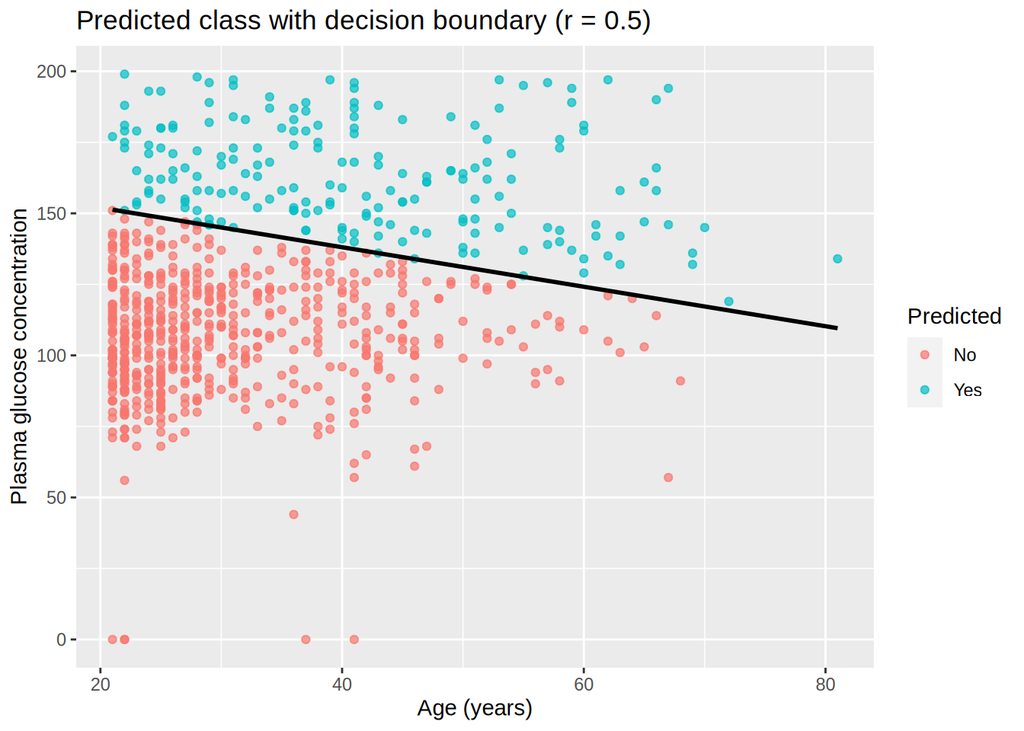

```r
# Decision boundary: theta0 + theta1 * glucose + theta2 * age = logit(r)
theta <- coef(model)
boundary <- function(age, r) (log(r / (1 - r)) - theta[1] - theta[3] * age) / theta[2]

ggplot(df, aes(x = age, y = glucose, colour = pred)) +
  geom_point(alpha = 0.7) +
  geom_function(fun = function(a) boundary(a, r), colour = "black", linewidth = 1) +
  labs(title = "Predicted class with decision boundary (r = 0.5)",
       x = "Age (years)", y = "Plasma glucose concentration", colour = "Predicted")
```

The decision boundary is linear in (age, glucose): older patients are classified as diabetic at lower glucose levels.

### Effect of the threshold

```r
for (r in c(0.2, 0.5, 0.8)) {
  cat(sprintf("r = %.1f  misclassification = %.4f  predicted positive = %.1f%%\n",
              r, misclassification(df$diabetes, df$prob, r), 100 * mean(df$prob > r)))
}
```

```
## r = 0.2  misclassification = 0.3724  predicted positive = 65.9%
## r = 0.5  misclassification = 0.2630  predicted positive = 25.3%
## r = 0.8  misclassification = 0.3151  predicted positive = 6.0%
```

Lowering the threshold to 0.2 flags far more patients as diabetic (higher sensitivity, more false positives); raising it to 0.8 does the opposite. In a screening setting, a lower threshold may be preferable even though the overall error rate increases.

## Basis function expansion

To allow a non-linear decision boundary, we add polynomial features of the two predictors:

$$z_1 = x_1^4,\quad z_2 = x_1^3 x_2,\quad z_3 = x_1^2 x_2^2,\quad z_4 =
x_1 x_2^3,\quad z_5 = x_2^4$$

where $x_1$ is glucose and $x_2$ is age. Features are standardised to keep the optimisation stable.

```r
x1 <- df$glucose
x2 <- df$age
expanded <- data.frame(
  diabetes = df$diabetes,
  glucose = x1, age = x2,
  z1 = x1^4, z2 = x1^3 * x2, z3 = x1^2 * x2^2, z4 = x1 * x2^3, z5 = x2^4
)
expanded[, -1] <- scale(expanded[, -1])

model_expanded <- glm(diabetes ~ ., data = expanded, family = binomial)
prob_expanded <- predict(model_expanded, type = "response")
cat("Training misclassification rate (basis expansion):",
    round(misclassification(df$diabetes, prob_expanded, 0.5), 4))
```

```
## Training misclassification rate (basis expansion): 0.2448
```

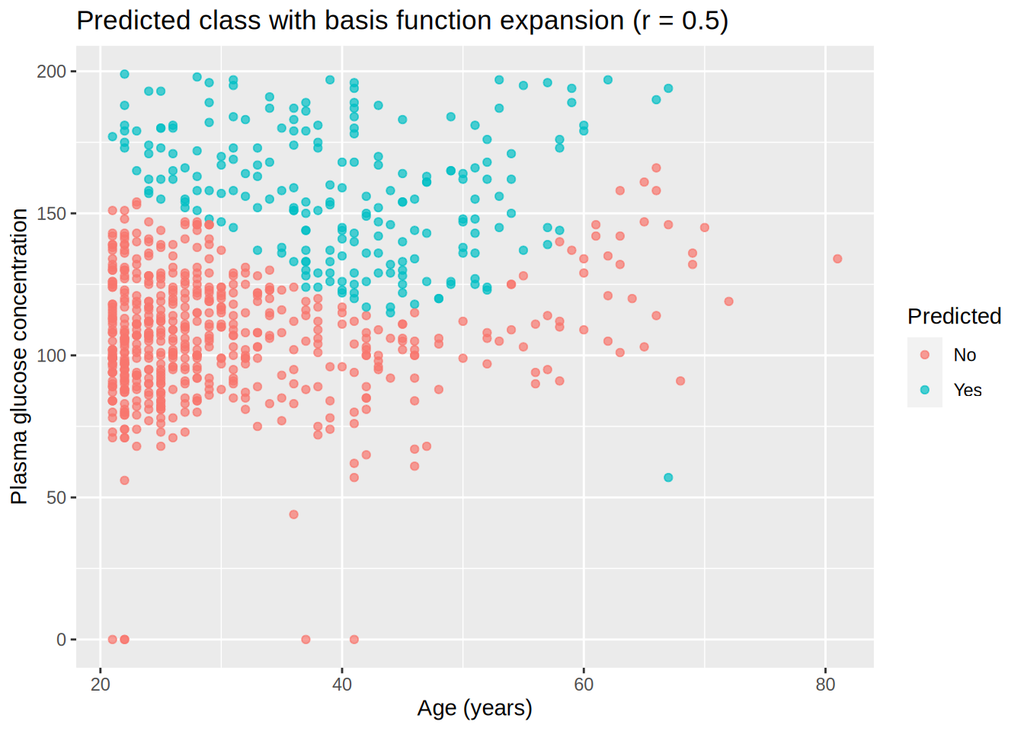

```r
df$pred_expanded <- factor(as.integer(prob_expanded > 0.5), levels = c(0, 1),
                           labels = c("No", "Yes"))
ggplot(df, aes(x = age, y = glucose, colour = pred_expanded)) +
  geom_point(alpha = 0.7) +
  labs(title = "Predicted class with basis function expansion (r = 0.5)",
       x = "Age (years)", y = "Plasma glucose concentration", colour = "Predicted")
```

## Conclusions

- Glucose is the strongest predictor of diabetes; age adds a smaller but significant positive effect.
- Plain logistic regression produces a **linear** decision boundary in (age, glucose) with a training misclassification rate of about **26%** at r = 0.5.
- The classification threshold trades sensitivity against specificity and should be chosen according to the cost of missed diagnoses versus false alarms.
- Basis function expansion lets the model learn a **curved** boundary and lowers the training misclassification rate to about **24%**. Its true benefit should be judged on held-out data, since extra flexibility also increases the risk of overfitting.